# Reproducible Research week-2 Project

Vasudha Singh

December 7, 2018

## 1.Loading and preprocessing the data

Load the data and transform the data into a format suitable for analysis

```r
knitr::opts_chunk$set(echo = TRUE)

download.file("https://d396qusza40orc.cloudfront.net/repdata%2Fdata%2Factivity.zip", destfile="actvitiy.zip", method="auto")
unzip("actvitiy.zip")
actdata<- read.csv("activity.csv")
str(actdata)
```

```
## 'data.frame':    17568 obs. of  3 variables:
##  $ steps   : int  NA NA NA NA NA NA NA NA NA NA ...
##  $ date    : Factor w/ 61 levels "2012-10-01","2012-10-02",..: 1 1 1 1 1 1 1 1 1 1 ...
##  $ interval: int  0 5 10 15 20 25 30 35 40 45 ...
```

```r
head(actdata)
```

```
##   steps       date interval
## 1    NA 2012-10-01        0
## 2    NA 2012-10-01        5
## 3    NA 2012-10-01       10
## 4    NA 2012-10-01       15
## 5    NA 2012-10-01       20
## 6    NA 2012-10-01       25
```

```r
summary(actdata)
```

```
##      steps                date          interval
##  Min.   :  0.00   2012-10-01:  288   Min.   :   0.0
##  1st Qu.:  0.00   2012-10-02:  288   1st Qu.: 588.8
##  Median :  0.00   2012-10-03:  288   Median :1177.5
##  Mean   : 37.38   2012-10-04:  288   Mean   :1177.5
##  3rd Qu.: 12.00   2012-10-05:  288   3rd Qu.:1766.2
##  Max.   :806.00   2012-10-06:  288   Max.   :2355.0
##  NA's   :2304     (Other)   :15840
```

## Load libraries

```r
library(dplyr)
```

```r
library(ggplot2)
```

## 2. What is mean total number of steps taken per day?

For this part of the assignment, you can ignore the missing values in the dataset.

```r
act.complete<- na.omit(actdata)
```

### (a) Calculate the total number of steps taken per day

```r
steps_per_day<- aggregate(act.complete$steps, by=list(act.complete$date), FUN=sum)
colnames(steps_per_day)<-c("Date", "TotalSteps")
head(steps_per_day)
```

```
##         Date TotalSteps
## 1 2012-10-02        126
## 2 2012-10-03      11352
## 3 2012-10-04      12116
## 4 2012-10-05      13294
## 5 2012-10-06      15420
## 6 2012-10-07      11015
```

### (b) Make a histogram of the total number of steps taken each day

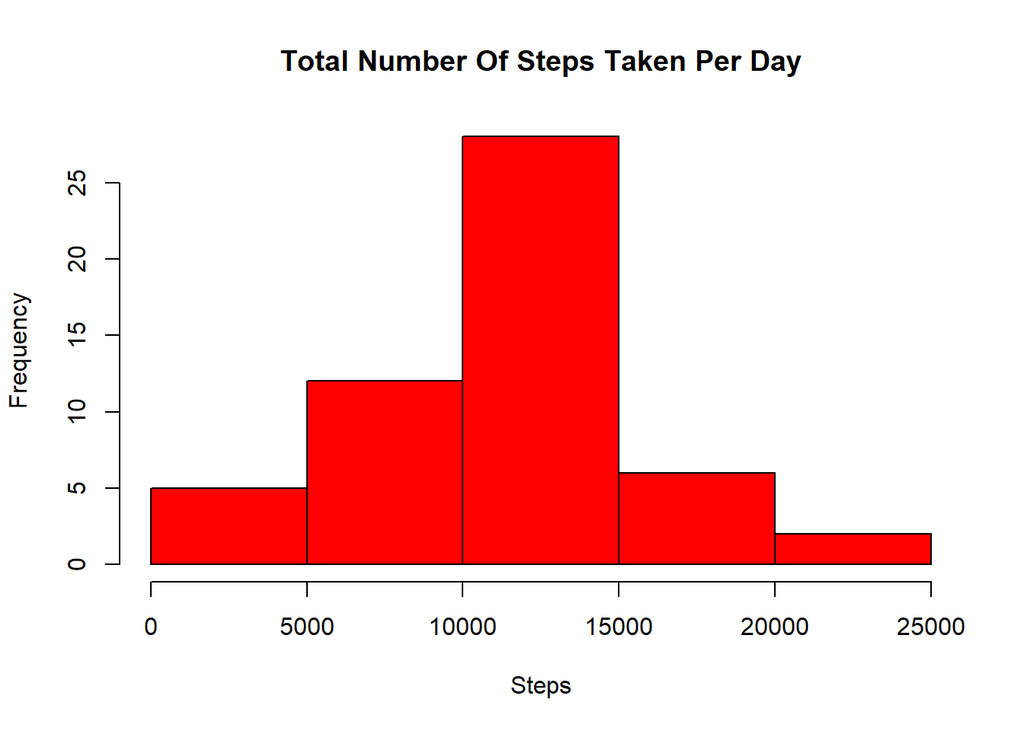

```r
hist(steps_per_day$TotalSteps, col="red",xlab ="Steps", ylab ="Frequency", main = "Total Number Of Steps Taken Per Day")
```

###(c)Calculate and report the mean and median of the total number of steps taken per day

```r
mean(steps_per_day$TotalSteps)
```

```
## [1] 10766.19
```

```r
median(steps_per_day$TotalSteps)
```

```
## [1] 10765
```

The **MEAN** is 10766.19 and the **MEDIAN** is 10765

## What is the average daily activity pattern?

### (a) Make a time series plot (type=“l”) of the 5-minute interval (x-axis) and the average number of steps taken, averaged across all days (y-axis)

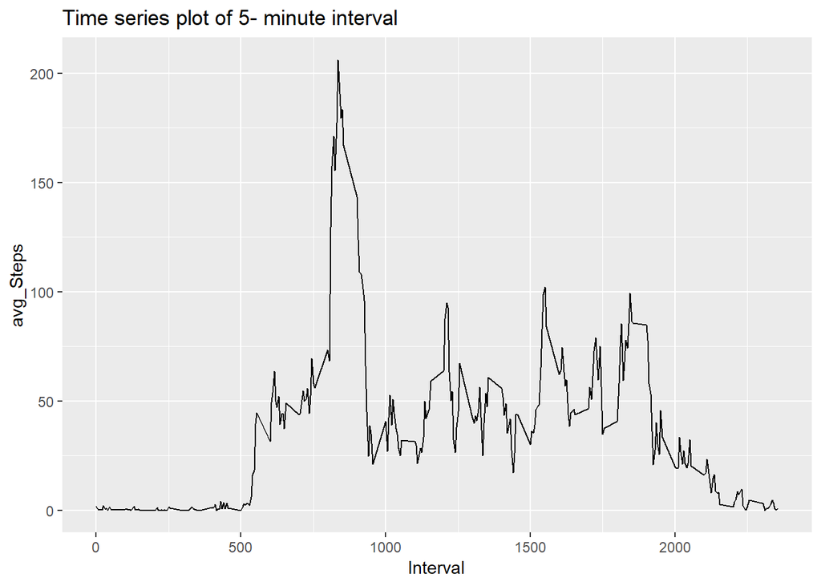

```r
steps_per_int<- aggregate(act.complete$steps, by=list(act.complete$interval), FUN=mean)
colnames(steps_per_int)<-c("interval", "avg_Steps")

ggplot(steps_per_int,aes(x=interval, y=avg_Steps))+geom_line()+ labs(x="Interval", ylab=" avg_Steps", title="Time series plot of 5- minute interval")
```

### (b) Which 5-minute interval, on average across all the days in the dataset, contains the maximum number of steps?

```r
steps_per_int[which(steps_per_int$avg_Steps==max(steps_per_int$avg_Steps)),]
```

```
##     interval avg_Steps
## 104      835  206.1698
```

5-minute interval that contain a Maximum number of steps is 835

## Imputing missing values

### (a)Calculate and report the total number of missing values in the dataset (i.e. the total number of rows with NAs)

```r
sapply(X=actdata, FUN=function(x) sum(is.na(x)))
```

```
##    steps     date interval
##     2304        0        0
```

The total number of Missing Value in dataset is **2304**

### (b)Devise a strategy for filling in all of the missing values in the dataset. The strategy does not need to be sophisticated. For example, you could use the mean/median for that day, or the mean for that 5-minute interval, etc.

```r
replacewithmean <- function(x) replace(x, is.na(x), mean(x, na.rm=TRUE))
meanday <- actdata%>% group_by(interval)  %>% mutate(steps= replacewithmean(steps))
head(meanday)
```

```
## # A tibble: 6 x 3
## # Groups:   interval [6]
##    steps date       interval
##    <dbl> <fct>         <int>
## 1 1.72   2012-10-01        0
## 2 0.340  2012-10-01        5
## 3 0.132  2012-10-01       10
## 4 0.151  2012-10-01       15
## 5 0.0755 2012-10-01       20
## 6 2.09   2012-10-01       25
```

### (c)Create a new dataset that is equal to the original dataset but with the missing data filled in

```r
new_dataset <-as.data.frame(meanday)
head(meanday)
```

```
## # A tibble: 6 x 3
## # Groups:   interval [6]
##    steps date       interval
##    <dbl> <fct>         <int>
## 1 1.72   2012-10-01        0
## 2 0.340  2012-10-01        5
## 3 0.132  2012-10-01       10
## 4 0.151  2012-10-01       15
## 5 0.0755 2012-10-01       20
## 6 2.09   2012-10-01       25
```

```r
summary(new_dataset)
```

```
##      steps                date          interval
##  Min.   :  0.00   2012-10-01:  288   Min.   :   0.0
##  1st Qu.:  0.00   2012-10-02:  288   1st Qu.: 588.8
##  Median :  0.00   2012-10-03:  288   Median :1177.5
##  Mean   : 37.38   2012-10-04:  288   Mean   :1177.5
##  3rd Qu.: 27.00   2012-10-05:  288   3rd Qu.:1766.2
##  Max.   :806.00   2012-10-06:  288   Max.   :2355.0
##                   (Other)   :15840
```

### (d)Make a histogram of the total number of steps taken each day and Calculate and report the mean and median total number of steps taken per day.

```r
tot_data_perday<-aggregate(new_dataset$steps, by=list(new_dataset$date), FUN=sum)
colnames(tot_data_perday)<- c("date","totalsteps")
head(tot_data_perday)
```

```
##         date totalsteps
## 1 2012-10-01   10766.19
## 2 2012-10-02     126.00
## 3 2012-10-03   11352.00
## 4 2012-10-04   12116.00
## 5 2012-10-05   13294.00
## 6 2012-10-06   15420.00
```

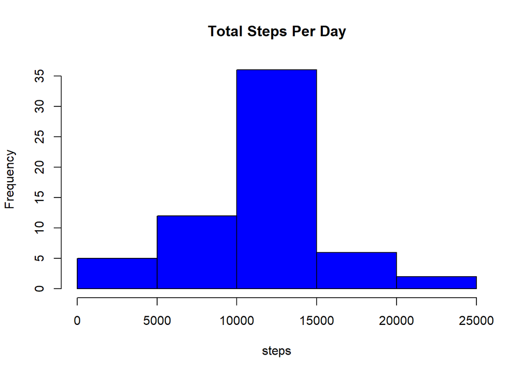

```r
hist(tot_data_perday$totalsteps, col="blue",xlab="steps", ylab="Frequency",main ="Total Steps Per Day")
```

```r
###New MEAN and MEDIAN
mean(tot_data_perday$totalsteps)
```

```
## [1] 10766.19
```

```r
median(tot_data_perday$totalsteps)
```

```
## [1] 10766.19
```

```r
###Old MEAN and MEDIAN
mean(steps_per_day$TotalSteps)
```

```
## [1] 10766.19
```

```r
median(steps_per_day$TotalSteps)
```

```
## [1] 10765
```

There is NO difference in value between old and new **MEAN**, but there is difference of **1.19** values between old and new **MEDIAN**.

#### Do these values differ from the estimates from the first part of the assignment? What is the impact of imputing missing data on the estimates of the total daily number of steps?

- Yes, the median value is differ from the estimates the first part of the assignment. The impact of imputing missing data of the total daily no. of steps is that it shifted towards the mean.

## Are there differences in activity patterns between weekdays and weekends?

For this part the weekdays() function may be of some help here. Use the dataset with the filled-in missing values for this part

### (a)Create a new factor variable in the dataset with two levels - “weekday” and “weekend” indicating whether a given date is a weekday or weekend day.

```r
new_dataset$weekend_day <-ifelse(weekdays(as.Date(new_dataset$date)) %in% c("Monday", "Teusday", "Wednesday","Thursday", "Friday"), "Weekday", "Weekend")
head(new_dataset)
```

```
##       steps       date interval weekend_day
## 1 1.7169811 2012-10-01        0     Weekday
## 2 0.3396226 2012-10-01        5     Weekday
## 3 0.1320755 2012-10-01       10     Weekday
## 4 0.1509434 2012-10-01       15     Weekday
## 5 0.0754717 2012-10-01       20     Weekday
## 6 2.0943396 2012-10-01       25     Weekday
```

### (b)Make a panel plot containing a time series plot (type = “l”) of the 5-minute interval (x-axis) and the average number of steps taken, averaged across all weekday days or weekend days (y-axis). See the README file in the GitHub repository to see an example of what this plot should look like using simulated data.

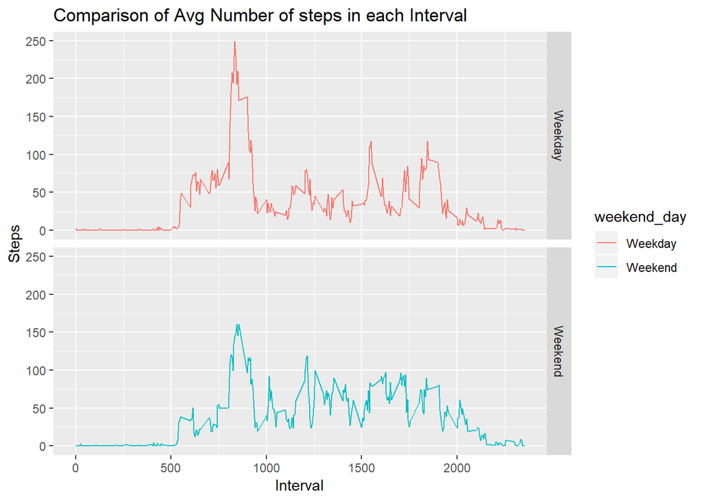

```r
meanWeek_end_day<- aggregate(new_dataset$steps, by=list(new_dataset$weekend_day, new_dataset$interval), mean )
colnames(meanWeek_end_day)<- c("weekend_day","interval","steps")

ggplot(meanWeek_end_day, aes(x= interval, y=steps, color= weekend_day))+ geom_line()+ facet_grid(weekend_day ~ .) + labs(x="Interval", y="Steps", title = "Comparison of Avg Number of steps in each Interval")
```